# Ripley’s K Function

Mohammad Samsul Alam

2022-07-11

```r
library(tidyverse)
library(dplyr)
library(ggplot2)
library(spatstat)
```

```r
dat<-swedishpines
dat
```

```
## Planar point pattern: 71 points
## window: rectangle = [0, 96] x [0, 100] units (one unit = 0.1 metres)
```

```r
dat %>%names()
```

```
## [1] "window"     "n"          "x"          "y"          "markformat"
```

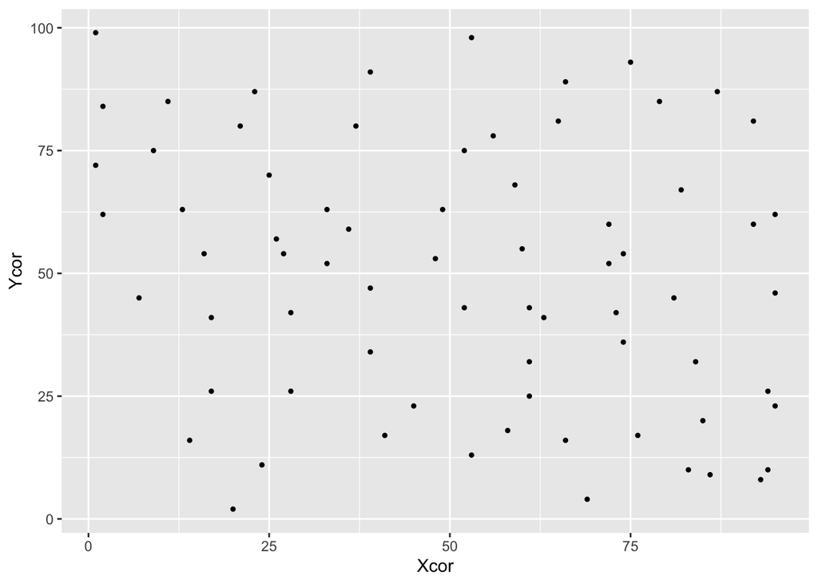

```r
n<-dat$n # no of events in the observed point pattern
xcor<-dat$x # X coordinates for the observed point pattern
ycor<-dat$y # Y coordinates for the observed point pattern
xlim<-dat$window$xrange # range in x-axis
ylim<-dat$window$yrange # range in y-axis
st_dom<-owin(xrange = xlim,yrange = ylim) # defining the study rectangular study domain
Data<-ppp(x=xcor,y=ycor,window = st_dom) # construction of data object for applying Kest function
data<-data.frame(Xcor=xcor,Ycor=ycor) # for ggplot purpose
ggplot(data,aes(Xcor,Ycor))+geom_point(pch=20) # visualiztion of the observed point pattern
```

### The Ripley’s $\mathcal{K}$ Function

- The $\mathcal{K}$ function is defined as,
  $$\begin{align*}
  \mathcal{K}(h) = \lambda^{-1}E&\left(\mbox{number of extra
  events within distance $h$}\right.\\&\left.\mbox{of an arbitrary
  event}\right),
  \end{align*}$$
  where $E()$ is our normal expectation operator, and $\lambda$ is the intensity or mean number of events per unit area which is assumed constant throughout the study area.
- It is sometimes called the reduced second moment measure, because it is closely related to the second-order intensity of a stationary isotropic point process.
- Additionally, because the estimator counts numbers of events within a range of distances, it is not very efficient to work with sampled events.
- Assume that we have observed $n$ events in the bounded study region $\mathcal{R}$ with area $R$. Therefore, an estimate of the intensity for an isotropic process can be obtained as $\hat{\lambda} = n/R$.
- Therefore, the $\mathcal{K}$ function can be estimated for a distance $h$ as,
  $$\begin{align*}
  \hat{\mathcal{K}}(h) = \frac{R}{n^2}\underset{i\ne j}{\sum\sum}
  I_{h}(d_{ij}),
  \end{align*}$$
  where, $d_{ij}$ is the distance between points $i$ and $j$, and $I_{h}(d_{ij})$ is an indicator function defined as follows,
  $$\begin{align*}
  I_{h}(d_{ij})=\left\{
  \begin{array}{ll}
  1&\mbox{ if } d_{ij}\le h\\
  0&\mbox{ otherwise}
  \end{array}\right.
  \end{align*}$$
- If the observed pattern exhibit regularity then $\hat{\mathcal{K}}(h)$ will be smaller than $\pi h^{2}$. Alternatively, if the observed pattern has clustering tendency then $\hat{\mathcal{K}}(h)$ will be greater than $\pi h^{2}$.
- However, the summation above necessarily excludes pairs of events for which the second event is outside $\mathcal{R}$. As a result, edge effect arises in the estimation of $\mathcal{K}$ function. Ignoring such edge effect we will get a biased estimate $\hat{\mathcal{K}}(h)$.
- A variety of edge-corrected estimators have been proposed. However, the most commonly used one is due to Ripley $(1976)$ which is defined as,
  $$\begin{align*}
  \hat{\mathcal{K}}(h) = \frac{R}{n^2}\underset{i\ne j}{\sum\sum}
  \frac{I_{h}(d_{ij})}{w_{ij}},
  \end{align*}$$
  where, $w_{ij}$ is the weight for pair $(i,j)$ which is the proportion of the circumference of a circle centered at location of the event $i$ and passing through location of the event $j$ that lies in $\mathcal{R}$, and other notations have similar meanings as defined earlier.
- Other edge corrections are also available such as toroidal edge correction, edge correction based on the guard area, and variable-width edge correction etc. (see for detail Cressie, $1993$).

```r
ks<-Kest(Data,correction=c("none","Ripley")) # estimated Ripley's K function.
ks_ggdat<-as.data.frame(ks) %>%pivot_longer(cols = c("theo","un","iso"),values_to = "Est_K",names_to = "Type") # construction of a data frame for ggplot2
ks_ggdat %>%head() # visualize the data frame
```

```
## # A tibble: 6 × 3
##        r Type    Est_K
##    <dbl> <chr>   <dbl>
## 1 0      theo  0
## 2 0      un    0
## 3 0      iso   0
## 4 0.0469 theo  0.00690
## 5 0.0469 un    0
## 6 0.0469 iso   0
```

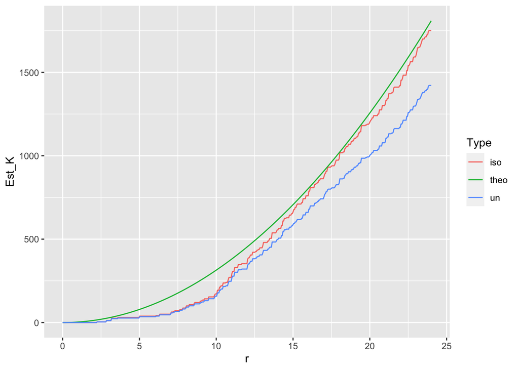

```r
ggplot(ks_ggdat,aes(x=r,y=Est_K,group=Type,col=Type))+geom_line() # plot of the estimated Ripley's K function
```